# AN/BI 588 - Homework 2

Bhavya Deepti Vadavalli

2023-09-28

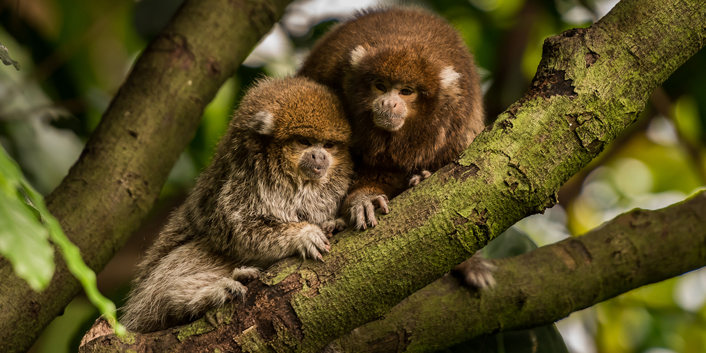

# It’s a Poisson distribution!

The scientist sits for a two hour session every Saturday morning.

lambda = mean number of calls per session = 15

X is the random variable that will denote the number of calls heard during a session.

## Question 1) What is the probability that she will hear more than 8 calls during any given session?

In order to find the probability that X > 8, we can calculate 1 - cdf (X = 8).

Here, cdf (X = x) really indicates an integral of pdf taken from X = 0 to x.

```r
#q1 is the pr (X > 8)
q1 <- 1 - ppois(q = 8, lambda = 15, lower.tail = TRUE)
#using the ppois() function to get the value of 1 - pr (X less than or equal to 8)
q1
```

```
## [1] 0.9625535
```

## Question 2) What is the probability that she will hear no calls in a session?

```r
q2 <- dpois(x = 0, lambda = 15)
q2 #the probability is very small!
```

```
## [1] 3.059023e-07
```

## Question 3) What is the probability that she will hear exactly 3 calls in a session?

Since, this question only asks us to calculate the Pr (X = 3), dpois() is the relevant function to use.

```r
q3 <- dpois(x = 3, lambda = 15)
q3
```

```
## [1] 0.0001720701
```

## Question 4) Plot the relevant Poisson mass function over the values in range 0 ≤ x ≤ 30.

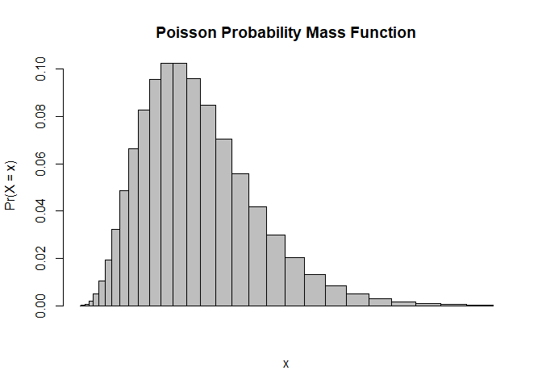

```r
x <- 1:30

pdf <- dpois(x = x, lambda = 15) #pdf is the function for the poisson function between X = 0 and 30.

#Plotting the function
barplot(pdf, x, space = 0, xlab = "x", ylab = "Pr(X = x)",
        main = "Poisson Probability Mass Function")
```

## Question 5) Simulate 104 results from this distribution.

```r
n = 104 #number of simulations
sim <- rpois(n = 104, lambda = 15)
```

## Question 6) Plot the simulated results using hist() and use xlim() to set the horizontal limits to be from 0 to 30. How does your histogram compare to the shape of the probability mass function you plotted above

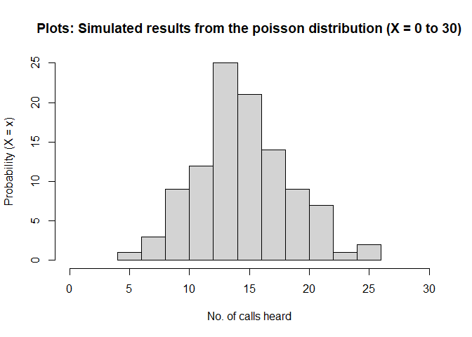

```r
hist(sim, xlim = range(0:30),
     main = "Plots: Simulated results from the poisson distribution (X = 0 to 30)",
     xlab = "No. of calls heard", ylab = "Probability (X = x)")
```

## Peer Commentary

- Formatting: Your formatting looks good. Adorable titi picture! You could add a caption to the image if you wanted to practice making captions.
- Question 1: I like how well you explain your reasononing for this and the questions. I am also not sure about what the purpose is of using the lower.tail argument. When I didn’t include it, I got the same answer. Also, does your code account for not including the probability of x = 8?
- Questions 2 and 3: Very straightforward and looking good!
- Question 4: You state that you define values between 0 and 30, but in your actual code you have 1 to 30. Also, I cannot figure out why, but your barplot looks different than mine and the others I’ve seen. Everyone’s that I’ve seen has appeared to have the highest density around 15 but your highest densities occur at lower x values. I cannot see any difference in our codes that would explain this.
- Question 5: Good, clear code. If you wanted, you could set the seed for the random numbers so that the same numbers are produced every time the code is run.
- Question 6: Histogram is looking good. You have the y-axis labeled as probability but I think the hist() function might actually default to showing the number of counts/frequency in this case and you would have to use the argument freq = FALSE to get probabilities. Since the number of simulations is close to 100, the counts look really close to probabilities as percents.
- Also question 6: don’t forget to answer the question of how your simulated data histogram compares to the function’s barplot!
- Overall: Nice efficient, well-organized, and annotated code!